# Jericho Lawson

Visiting Assistant Professor at Vassar College

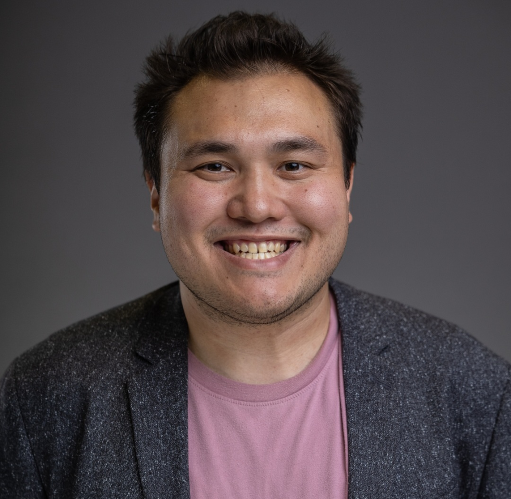

jblawson@vassar.edu  
[@jerichostats](https://x.com/jerichostats)  
jericholawson

I am currently a Visiting Assistant Professor at Vassar College. I have taught various statistics courses as a graduate student and lecturer, including Introduction to Statistical Modeling, Statistical Computing, Sampling Surveys, and Introduction to Data Science. My goal is for students to come out with a stronger foundational understanding of statistics, while also embracing the application and quirkiness of the field itself. While the field has paved the way for modern advances like automation and AI, it also grounds individuals with consistent process and inference, allowing us to identify traits of a population and solve problems.

- Seeing Theory: [link](https://seeing-theory.brown.edu/)
- Spurious Correlations: [link](https://www.tylervigen.com/spurious-correlations)

My research interests include high-dimensional variable selection, sports statistics, and deep learning. My current research aims to pinpoint useful abstract features within images for image classification through the knockoffs framework, called ImgKnock.

- Dissertation! [link](https://escholarship.org/uc/item/77403004)
- Detecting Glaucoma? [link](https://doi.org/10.1038/s41598-026-44662-7)

## Recent News

- **06/2026**: I will be heading to the Department of Mathematics and Statistics at Vassar College as a Visiting Assistant Professor for one year. I want to thank everyone, from students to colleagues, at Smith College who welcomed me in as I transitioned from my PhD program to the world of academia.